# Cameroon Peace Promotion Project

Christopher D. Grady

cdgrady2@illinois.edu

University of Illinois

&

Rebecca Chapman

rchapman@equalaccess.org

Equal Access International

May 25, 2017

# Overview

# Methodology

## Measurement Methodology

We often combine individual questions into one index that summarizes the results of those individual questions. This is done for questions that are intended to measure the same concept – for instance, acceptance of violence as a means to achieve goals. Individual questions can be combined into an index when they have *internal cosistency*; that is, when a high score on one question correlates to a high score on every other question in the index. High internal consistency indicates that the questions are all measuring one cohesive concept. The internal consistency of the index is measure by an alpha value, with higher values meaning more internal consistency. When an index has a high alpha value (0.7 and above), we will generally report only the index score to avoid redundancy.

The survey questions mainly use modified Likert scales. On our modified Likert scales, respondents are presented with a statement and asked the extent of their agreement or disagreement with that question. The options we use are (1) strongly agree, (2) somewhat agree, (3) somewhat disagree, and (4) strongly disagree. We do not enumerate a “don’t know” option to respondents, since research shows that certain demographic groups are systematically more likely to use don’t know responses, even when they are fairly certain of the answer (Krosnick 2002). Primarily, introverted people and people from disadvantaged groups (i.e. people with low education, women, etc…). Offering a “don’t know” response systematically decreases the representation of these people in the survey and increases the representation of people who are not afraid to guess even when they do not know the answer. These extroverted people tend to be older men, and so enumerating a “don’t know” response results in a survey that overrepresents older men. We instruct enumerators not to enumerate a “don’t know” response and only utilize “don’t know” if the respondent asserts that they cannot or do not wish to answer.

We also report survey-corrected statistics. In a survey, each respondent is not an independent data observation. Respondents are embedded in a social context (their neighborhood) with other respondents. Respondents in the same neighborhood tend to have similar attitudes, and so 100 respondents in one neighborhood tells us far less about an area than 100 respondents evenly spread throughout ten neighborhoods. The 100 respondents from one neighborhood will more accurately reflect the attitudes of that particular neighborhood, but not the wider area we wish to describe.

In this study, we surveyed 70 neighborhoods within 12 towns, or departments, in the north and extreme north regions of Cameroon. The number of neighborhoods surveyed per town was proportional to population, so that larger towns like Garoua (11 neighborhoods) have more representation than smaller towns like Maga (2 neighborhoods). Each neighborhood was meant to have 15 survey respondents, but due to enumerator errors the PSU sizes range from 10 to 20. We account for that by weighting responses such that respondents in PSUs with greater than 15 respondents are downweighted proportionally and respondents in PSUs with fewer than 15 respondents are upweighted proportionally. That method ensures that each PSU has equal weight when calculating the town characteristics.

We also report the error of our survey statistics (i.e. means and medians) based on bootstrap replicates. When we conduct a survey, we randomly select respondents from each neighborhood to answer survey questions. We know the survey responses could look a little different if random selection had generated different survey respondents. That difference is the error. We simulate how the survey responses *might have* looked if we conducted the survey again in the same neighborhood with a bootstrap procedure. The bootstrap procedure is to create new hypothetical surveys by randomly selecting with replacement the respondents from our actual survey. By conducting this bootstrapping procedure 1,000 times, we see what could have happened if we conducted 1,000 other surveys in the same locations. That creates a distribution of possible survey statistics – for example, a distribution of means. We use that distribution to specify the standard error of the mean.

For example, imagine that the average score on the violence index in our survevy is 0.7. We could imagine finding a mean of 0.65 or 0.75 if we talked to different people in that neighborhood. However, we could *not* imagine finding a mean of 0.2. No combination of people in the neighborhoods would yield so low an average. Bootstrapping quantifies the other means we could find and with what probability we would find them.

## Survey Sampling Methodology

This survey was conducted using a stratified two-level cluster sample design. The survey was stratified by department/town; we have every department/town in our target area. Within towns, we randomly select PSUs from a list obtained by workers on the ground. Within PSUs, the enumerators mapped out 75 households and randomly selected 15 of them (1/5th) through a systematic sampling procedure. And within selected households, enumerators randomly selected one respondent by assigning each household member a number and using a random number generator to select one number.

## Interpreting Survey Responses

Surveys are an extremely useful tool for summarizing opinions, but survey responses can easily be misinterpreted. Researchers must keep two main ideas in mind when analyzing survey responses. First, asking questions is complicated and each respondent interprets survey questions based on their own experiences. And second, at the individual-level, randomness enters into the responses to each question[^1].

First, we must put ourselves in the mind of the respondent and think how the respondent is going to interpret the question they are asked. This is true even of fairly straightforward questions. What does it mean when someone asks you if other religions promote peace and tolerance towards your religion? This depends on the mind of the respondent. The response to this question could be affected by (1) which religions enter the respondent’s mind, (2) if peace and tolerance are thought of in a positive sense (treat people well) or a negative sense (don’t treat people badly), and (3) what the respondent thinks the enumerator wants to hear. People carry many ideas around in their heads, and we cannot be sure precisely which idea influences their answers to a survey question. We still learn a great deal from looking at response patterns to a question asking if other religions promote peace and tolerance towards the respondent’s religion, but each respondent brings slightly different mental considerations to bear when answering questions.

Problems of question interpretation do not detract from the usefulness of a survey, it just forces the survey researcher to think about the meaning of the question. If large differences occur between subgroups in the population, it could be that subgroups have very different opinions about the same concept (the typical interpretation). But it could also mean that one subgroup interprets the question in a very different way than another subgroup. That is not the typical interpretation, but that is also extremely valuable information. If respondents interpret the question differently when asked the same question, with the same wording, in the same survey context, we learn a great deal about their worldview and outlook. It is important for survey researchers to theorize about *why* a respondent answered the way they did.

Second, we must keep in mind the “random noise” caveat. Every survey response contains some element of randomness[^2]. Some respondents have not thought about these topics or otherwise do not know what they think, and are being asked to form an opinion on the spot. Their responses hint at their underlying opinion, but may only reflect their attitude that is currently most salient, not their strongest attitude[^3]. The goal of a good survey question is to minimize the amount that randomness influences responses and maximize the amount that the concept of interest influences responses, but no questions is perfect.

This problem also does not detract from the usefulness of surveys as a tool to measure opinion. Problems of randomness are overcome by large numbers of survey respondents. Purely random responses will not show systematic preferences for differences and will center around the mean response. Think about a coin flip: if you flip a coin ten times and receive four heads and six tails, the evidence suggests the coin random. But if you flip a coin 1,000 times and receive 400 heads and 600 tails, evidence suggests that the coin is rigged. The underlying pattern shows through with large numberes. Likewise, if we ask 10 people who they will vote for and 6 say candidate A and 4 say candidate B, evidence suggests that candidate A and candidate B have about an equal amount of support. But if we ask 1,000 people and 400 say candidate A and 600 say candidate B, we should conclude that candidate B has much more support in the population[^4]. The increasing precision of large numbers is also the logic to using an index: individual questions have some measurement error, but even if the questions are 50% error and 50% concept measurement, that error is overwhelmed by the use of multiple questions to measure a single concept. The error is by definition random, whereas the concept measurement is directed.

## Summarizing the Survey

In the next section, we summarize the findings of the survey, disaggregating answers by gender, age, region, religion, and the language spoken for the survey. We display a graph for each question group, disaggregating by (1) gender, (2) age, (3) region, (4) religion[^5], and (5) interview language[^6]. The bars show the mean response of respondents in each group, and the error bars show the 95% confidence interval within which the mean *could* be.

# Demographics

## Gender, Age, and Ethnicity

## Education, Literacy, Language, and Religion

# Attitudes

## Social Contact

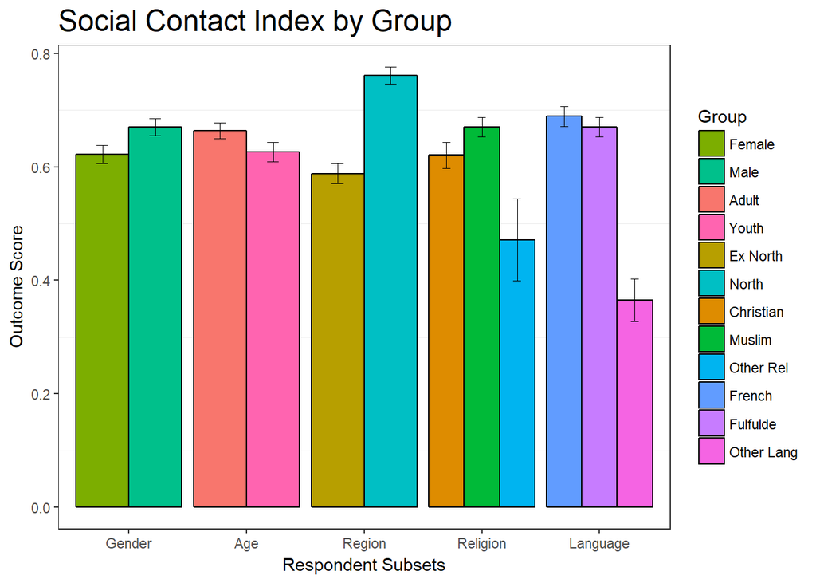

An important cause and consequence of intergroup tolerance is intergroup social contact. Intergroup contact has been shown in numerous studies to increase intergroup tolerance, and more tolerant people are also more likely to seek out intergroup contact. Here we measure social contact with three questions, combined into an index (alpha = 0.76). The index is scaled from 0-1 and higher scores indicates more contact with outgroups. The specific questions are about frequency of contact with (1) ethnic outgroups, (2) religious outgroups, and (3) foreigners.

## Cultural Understanding

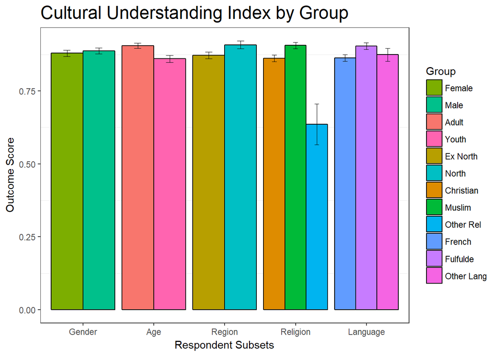

A perceived lack of cultural understanding often feeds the us vs. them narrative that underlies intergroup conflict. This survey measures both a respondent’s feeling that living in harmony with different types of people is important in their culture, and the respondent’s perception that various “others” understand and respect their culture. Those others are (1) people from other religions, (2) people from other ethnicities, (3) people from other regions of Cameroon, (4) political leaders, and (5) youth.

## Support for Women’s Empowerment

### Index

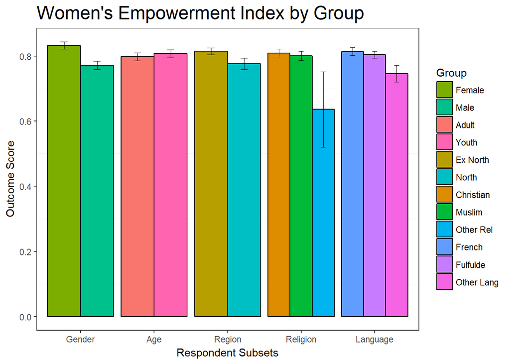

Women are often denied empowerment over their lives. Women are often denied the education of their male counterparts, a say in decisions that affect their communities, or even a choice in their marriage partner. The women’s empowerment index measures the extent to which respondents believe that women should have be empowered to the same extent as men. It contains four questions: (1) A woman should have a say in how her household spends money; (2) When a mother works for pay the children suffer; (3) An education is more important for a boy than a girl; and (4) It is not in the best interest of a girl to be married before she is 16 years old. All questions are coded so that higher scores indicate more support for women’s empowerment.

Unlike our previous indices, the alpha for the women’s empowerment index is only 0.58. This is not enough internal consistency of us to consider these questions as measuring the same concept. Therefore we now turn to analyses of the individual questions in the women’s empowerment index.

### Women Household Finances

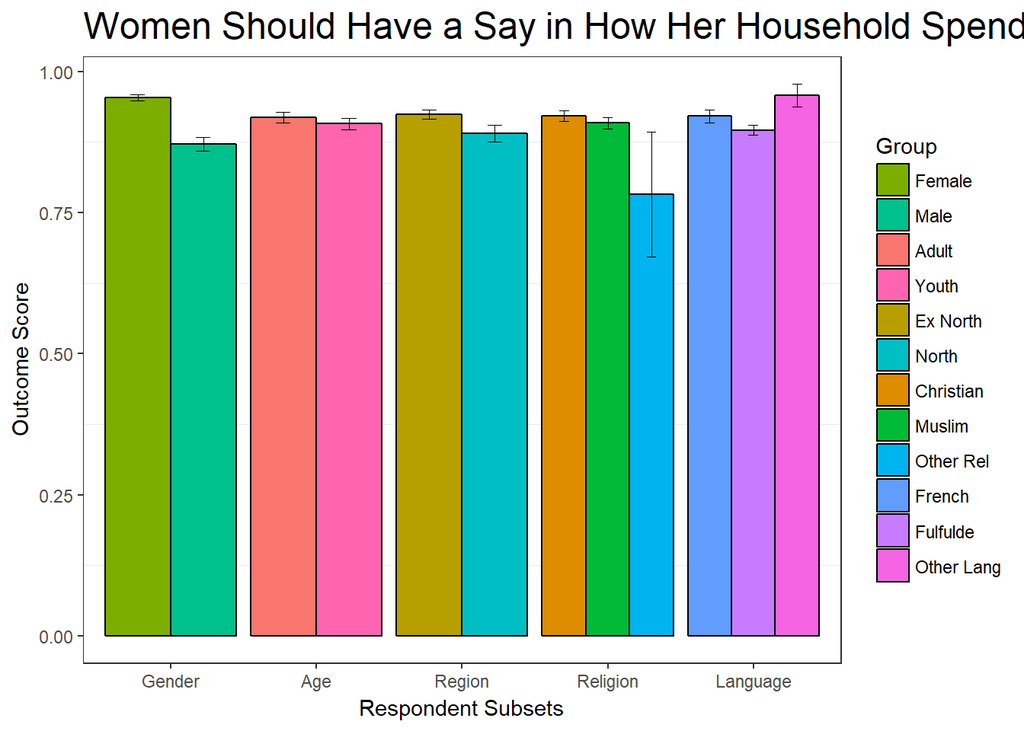

### Women Work for Pay

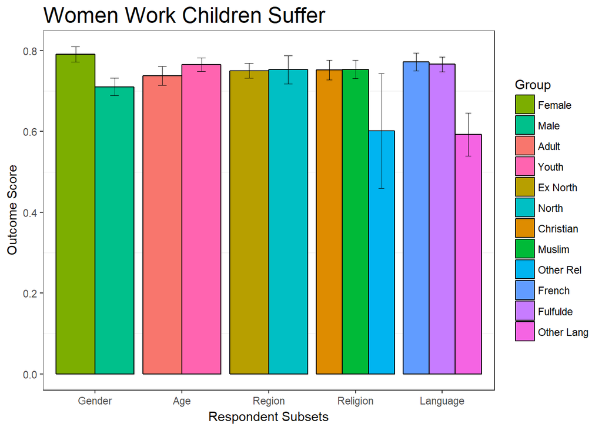

The second question in the women’s empowerment sequence asks if children suffer when women work for pay. The responses have been re-scaled in the analysis so that a 1 means a pro-empowerment response (strongly disagree) and a 0 means an anti-empowerment response (strongly agree). The mean score is about 0.73 on a scale from 0-1, indicating support for women, but less support than for the previous women’s empowerment question. However, this could easily be due to the reverse scaling of this question (making agreement normatively bad), and a persistent “agreement bias” wherein respondents are more likely to agree than disagree with survey statements. Again, women score higher than men. This time the non-French/Fulfulde speakers score lower than French/Fulfulde speakers[^7]

### Education of Boys and Girls

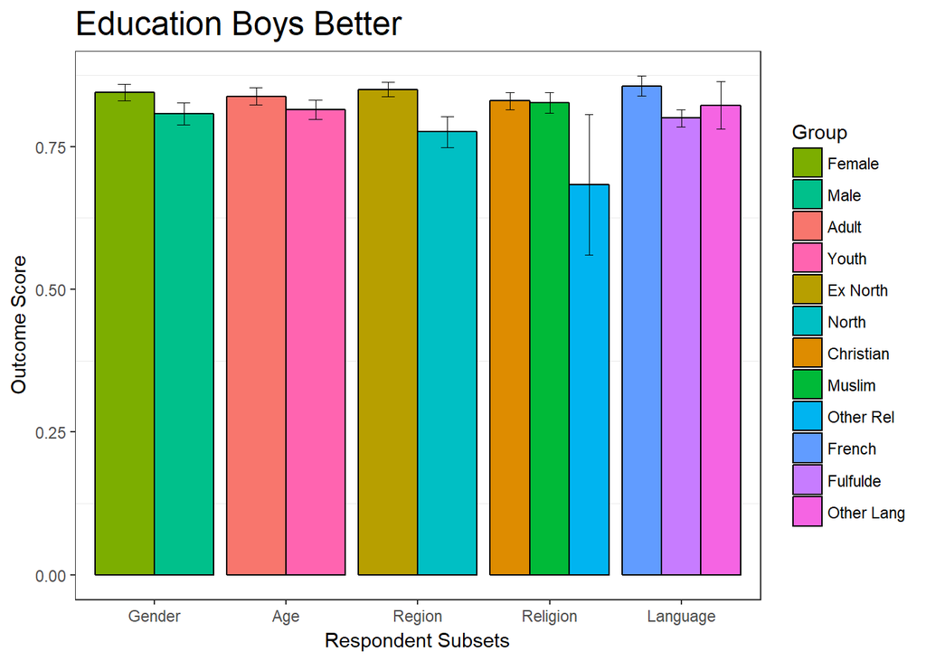

The third question in the women’s empowerment sequence asks respondents if education is more important for a boy than a girl. Unlike previous questions, there are *no statistical differences* between men and women. Women score slightly higher, but differences this small occur frequently due to chance. Differences appear by region and language spoken: people in the northern region and people answering the survey in Fulfulde are more likely to agree that education is more important for boys than girls.

### Early/Child Marriage

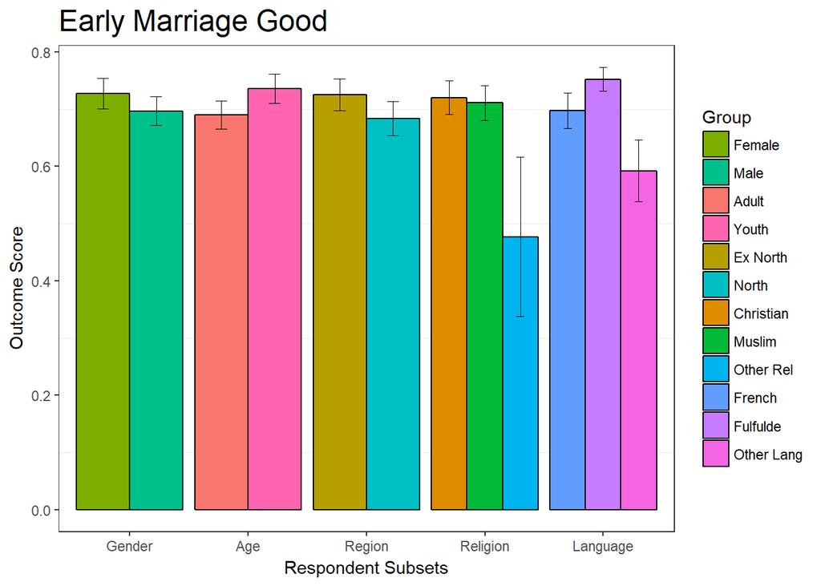

## Religious Tolerance

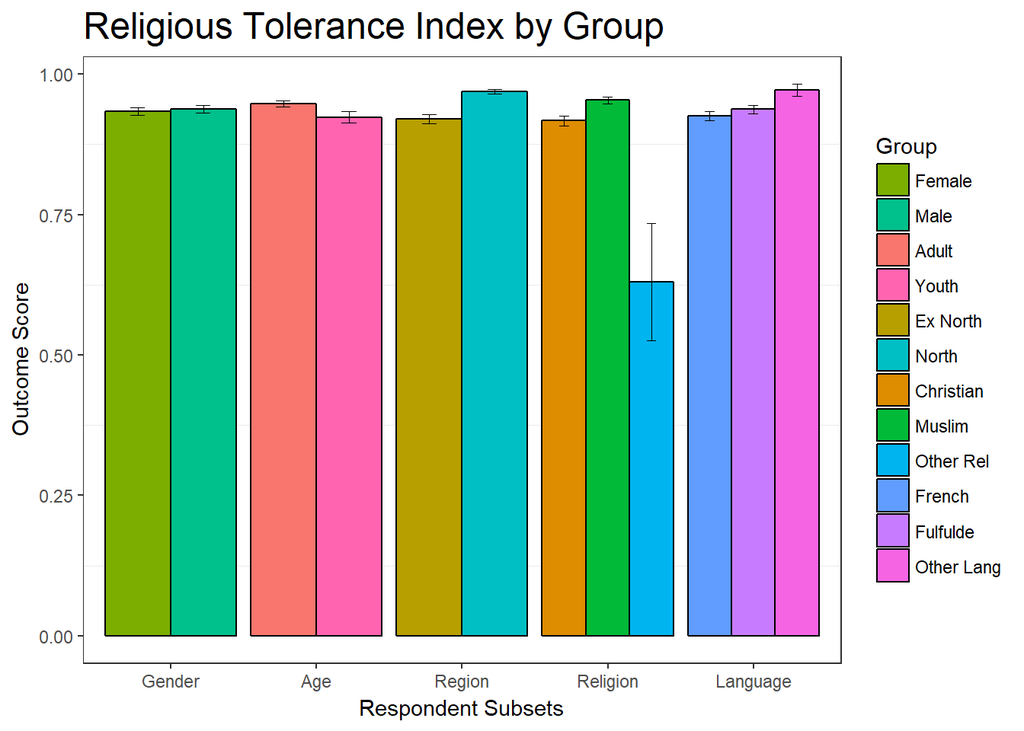

Though these questions for a reasonably strong index and “move together” (as the response to one question is more tolerant the likelihood of the others being tolerant increases strongly), the baseline values for these questions differ slightly by subgroug. Additionally, these questions measure distinct outcomes in themselves, even if those outcomes fit under the umbrella of religious tolerance. Therefore, we briefly discuss responses to each question.

### Valid Interpretations of Religion

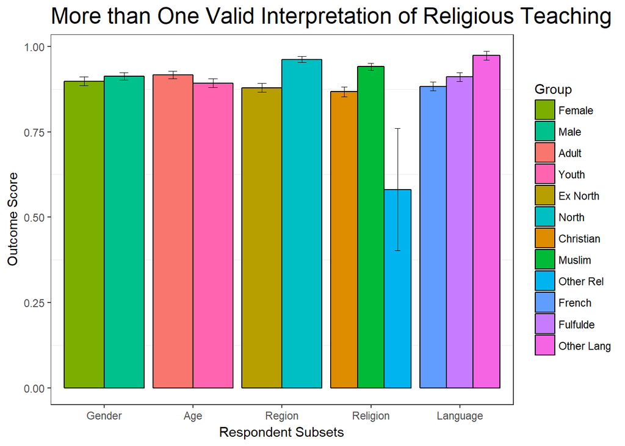

We asked respondents if they believed there was more than one valid interpretation of religion. The measurement intent here is that more religiously tolerant people will agree with this statement and the less religiously tolerant will not. The mean score is about 0.91 on a 0-1 scale, indicating overwhelming support for the idea of multiple valid interpretations of religion. But there are three differences by subgroup. First, respondents are far more supportive in the north than the extreme north. Second, Muslims are more supportive of this than Christians. And third, people who responded to the survey in another language were much more likely to agree.

### Religions Promote Peace and Tolerance

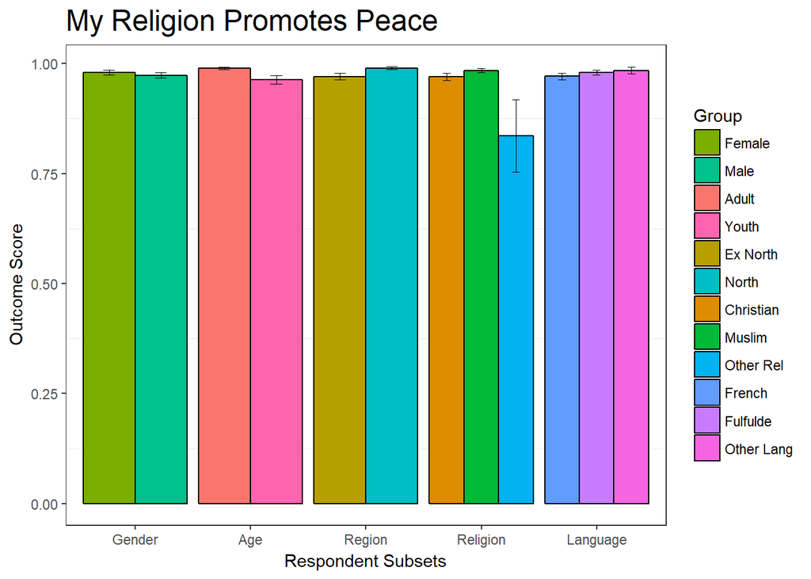

We asked respondents if they believed their religion promoted peace and tolerance towards people of other religions. The mean score is about 0.98 on a 0-1 scale, indicating universal support; almost everyone strongly agreed with this statement. There are no meaningful differences; everyone believes their religion is peaceful.

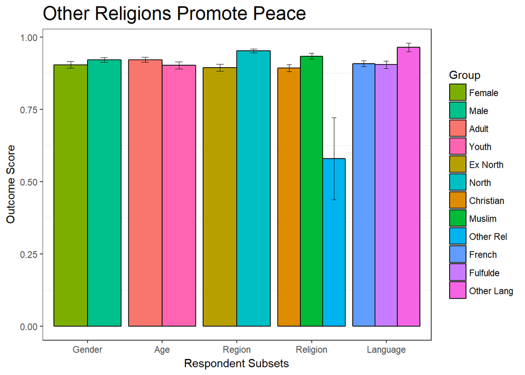

However, we also asked respondents if they believed other religions promoted peace and tolerance towards people of their religions. The mean score is about 0.91 on a 0-1 scale, indicating widespread support but not universal support. People in the north are more likely to agree than people in the extreme north, and people who speak a language other than French/Fulfulde are again more likely toa gree. In an interesting religious difference, Muslims are slightly more likely than Christians to agree that other religions promote peace towards their religion.

### People of Different Religions Live Together Peacefully

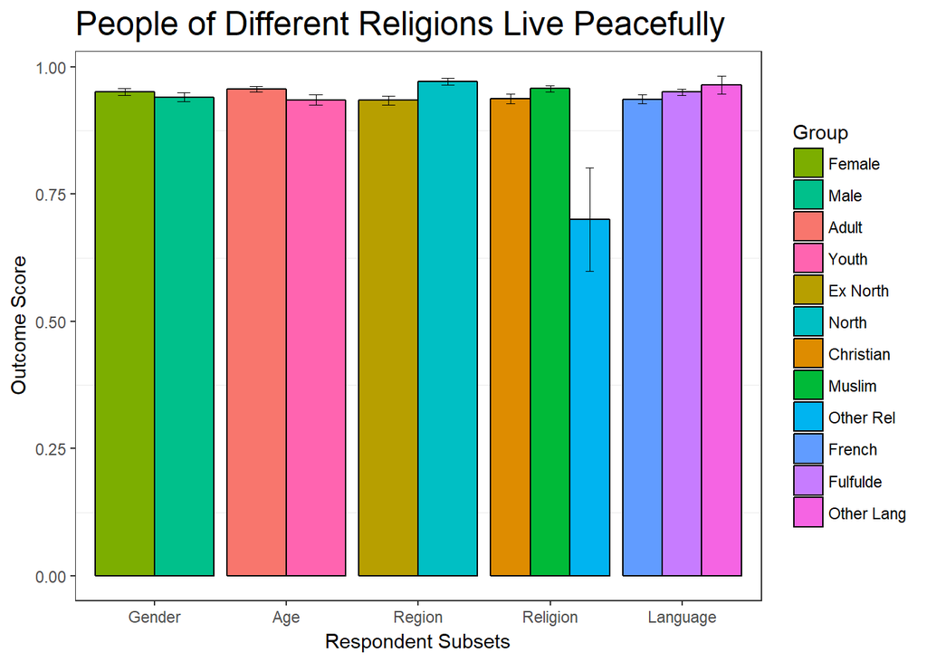

Respondents were also asked if people of different religions live together peacefully in their community, to which all subsets respondents overwhelingly agreed. People in the northern region are slightly more likely to strongly agree than respondents in the extreme north, but the difference is between 0.97 and 0.94 on the 0-1 scale and so not substantively interesting.

## Political/Civic Engagement

We asked four questions about community and civic engagement. (1) There is good political transparency in my community and citizens are informed of government actions; (2) People in my community do not vote and are not engaged in civic matters; (3) Corruption is a problem in my community; and (4) People in my community give their time or money to solve community problems, such as cleaning out gutters, building schools, wells, or bridges, etc. All questions are recoded from 0-1 so that 0 is a normatively undesirable response (i.e. strongly agree corruption is a problem or strongly disagree people give time and money to solve community problems) and 1 is a normatively desirable response.

These questions do not form a reliable index (as scores on one increase the scores on the others do not increase). Therefore, these cannot be treated as representing an underlying concept and we discuss each in turn.

### Political Transparency

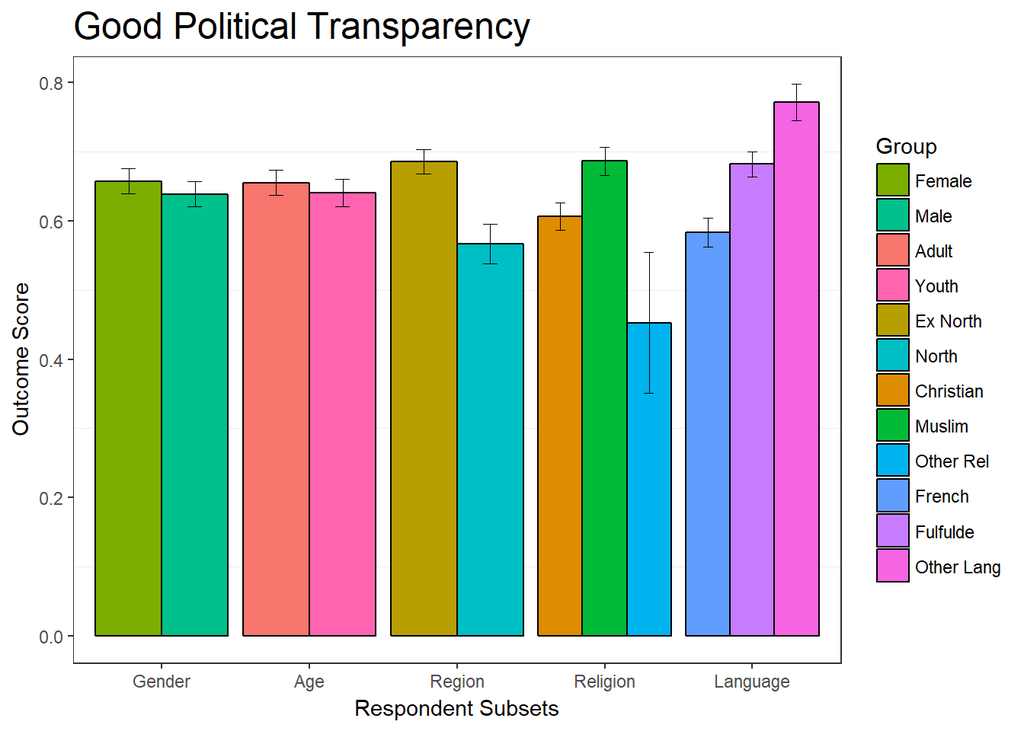

### Voting and Civic Engagement

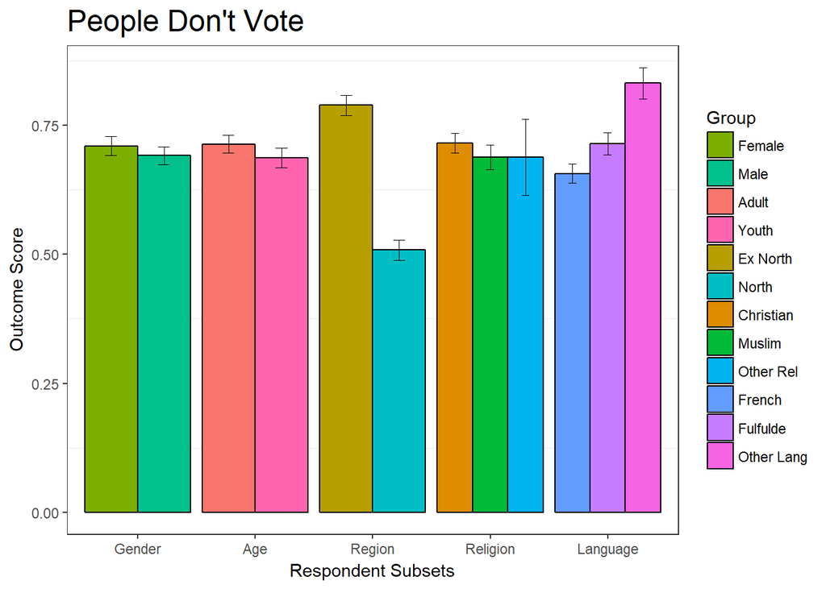

We asked respondents if they believed people in their community do not vote and are not engaged in civic matters. This question is scaled so that strong agreement is a 0 and strong disagreement a 1. The mean score is about 0.71 on a 0-1 scale, indicating generally a belief that people are involved in civic matters, but some ambivalence on the part of many respondents. The ambivalence is almost entirely from people in the northern region. In the extreme north, about 66% of people strongly disagree that people do not vote and are not engaged civically. But in the north only abotu 14% of people strongly disagree with that statement. And we again see the pattern by language wherein French speakers are the most pessimistic about their community and non-French/Fulfulde speakers the most optimistic.

### Corruption

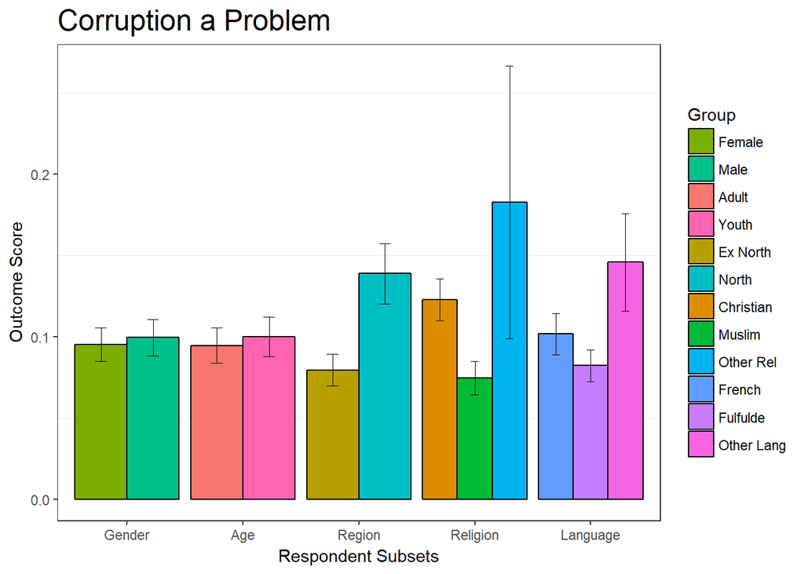

We asked respondents if they believed that corruption is a problem in their community. This question is scaled so that strong agreement is a 0 and strong disagreement a 1. The mean score is about 0.09 on a 0-1 scale, indicating that almost all respondents believe corruption to be a problem. There are small differences in magnitude of concern about corruption, but agreement that corruption is a problem. People in the extreme north perceive more corruption than people in the north, and Muslims perceive more corruption than Christians.

### Community Problem Solving

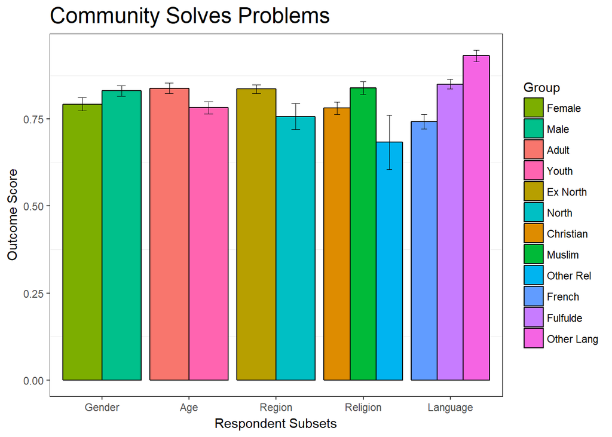

## Other Religious and Ethnic Group Feelings

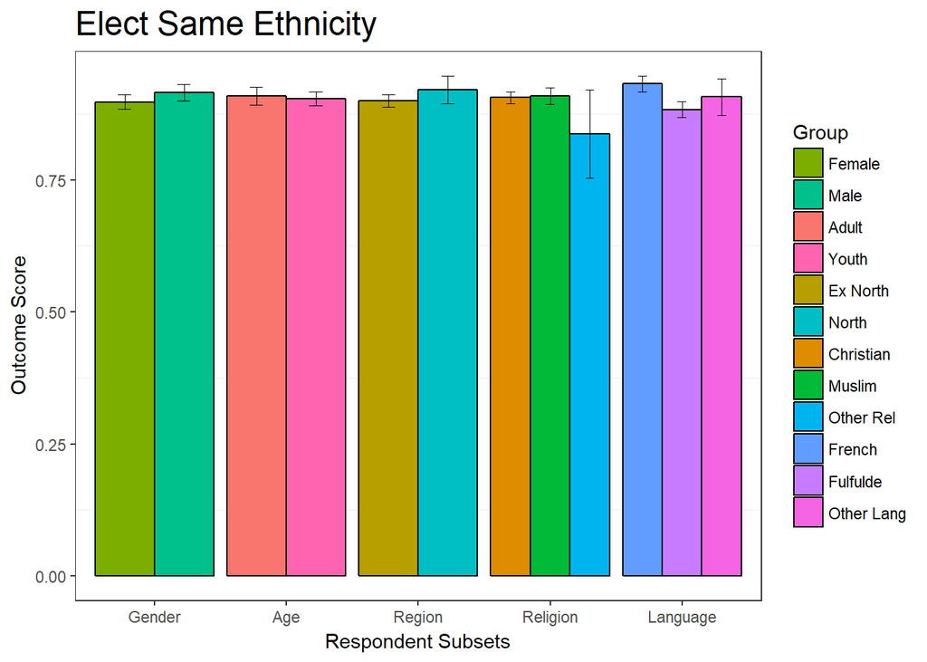

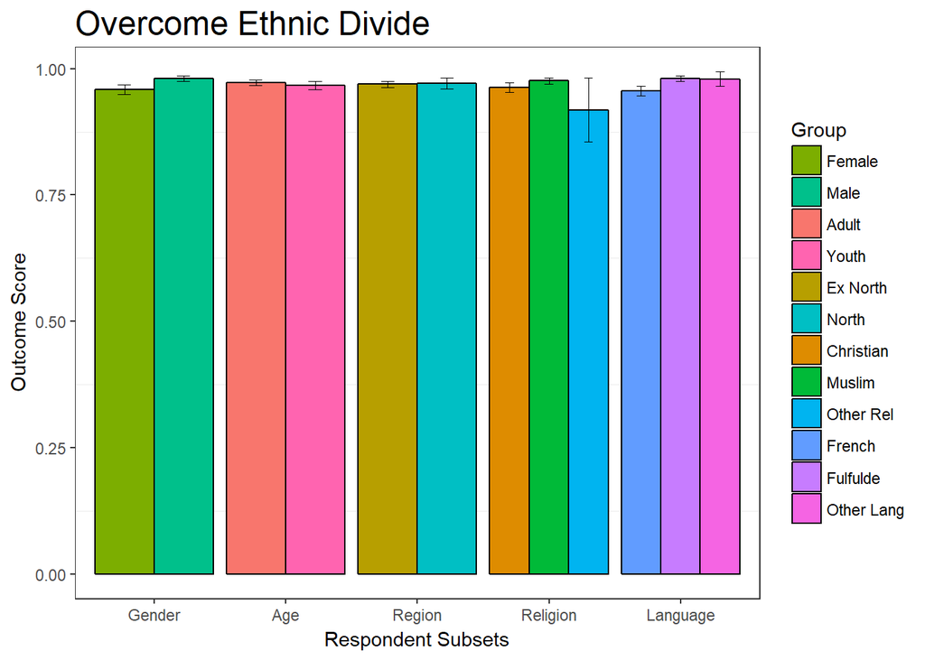

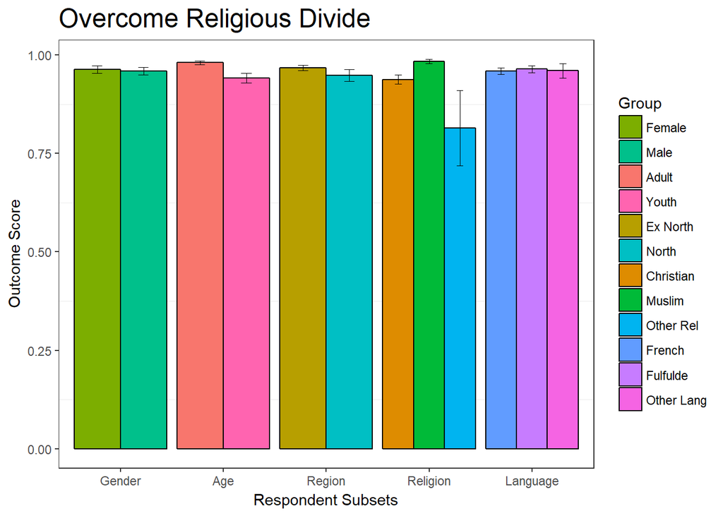

We asked three questions to measure attitudes related to religious and ethnic outgroups in society[^8]. These questions use binary response outcomes (yes or no) are not intended to be used as an index, so we report them individually. The questions are:

- 1. In elections, people in Cameroon often vote for candidates from their own ethnic group. Which of the following statements is closer to your view? (1) It is normal to want to elect someone from your ethnic community, OR (2) Voters should place much less emphasis on ethnic considerations.
- 2. Differences often exist between people living in the same village/neighborhood. Would you say that ethnic differences tend to divide people in your village/neighborhood, or do people in your village/neighborhood tend to overcome their ethnic differences?
- 3. Would you say that that religious differences tend to divide people in your village/neighborhood, or do people in your village/neighborhood tend to overcome their ethnic differences?

The first question measures their belief in using ethnicity as a reason to vote for a political candidate, and the next two reflect the respondent’s perception about acceptance of ethnic and religious outgroups in their communities.

For the first question, about 91% of respondents do not believe ethnicity should be important when deciding an elected candidate. This is roughly the same proportion for all subsets of the data, but Fulfulde speakers are ever so slightly more likely to believe ethnic voting is acceptable. For the second question asking if people in the respondent’s community overcome ethnic divides, about 97% say yes, with no meaningful differences between subgroups.

For the final question asking if people in the respondent’s community overcome religious divides, about 96% of people say yes. There are small but significant differences by subgroup. Importantly, Christians are less likely to perceive religious differences as overcome than Muslims[^9]. Youth are also less likely to think their communities overcome religious differences than adults, as are northerners compared to extreme northerners. However, even for the subgroups who are less likely to perceive religious divides as overcome, the vast majority of people in those subgroups *do* perceive the divides as overcome.

## Efficacy and Empowerment

In many contexts, good people feel helpless against the violence and crime they perceive in their communities. Empowering the good, tolerant, non-violent people is a major goal of any peace-building program, and this survey asks four questions to measure the empowerment people feel in changing their communities for the better:

- I am going to read you two statements. Please listen to both, and then tell me which one of them is closer to your view. (1) As an individual citizen, I have the ability to create positive change in my community, (2) The ability to make positive changes in my community rests with those who have more power than I do
- Violence and insecurity are a problem in my community.
- People in my community have the power to speak out against violence
- I know how to seek legal recourse for myself or a loved one if a law is broken.

The first question about creating change uses binary response options, and the second, third, and fourth questions are all 4-point scales from strongly agree to strongly disagree. These questions are not intended to measure separate concepts, not a single underlying psychological concept, and so are considered separately, not as an index.

### Power to Affect Positive Change

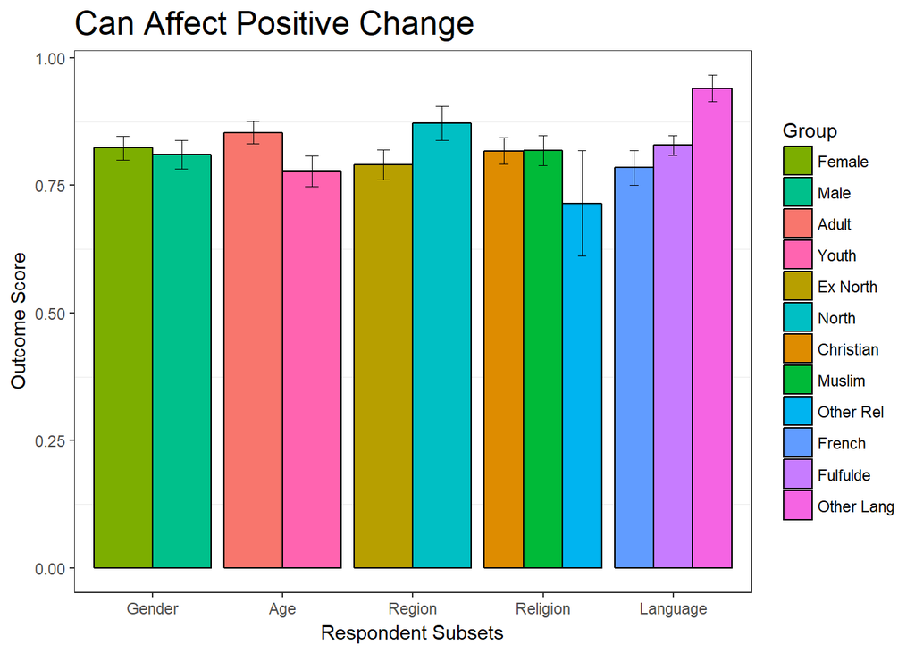

### Violence a Problem and Power to Speak Against Violence

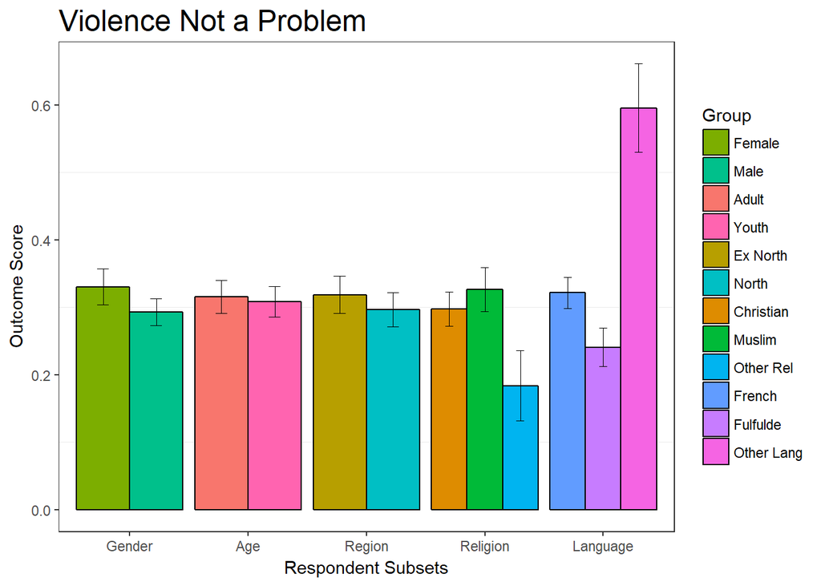

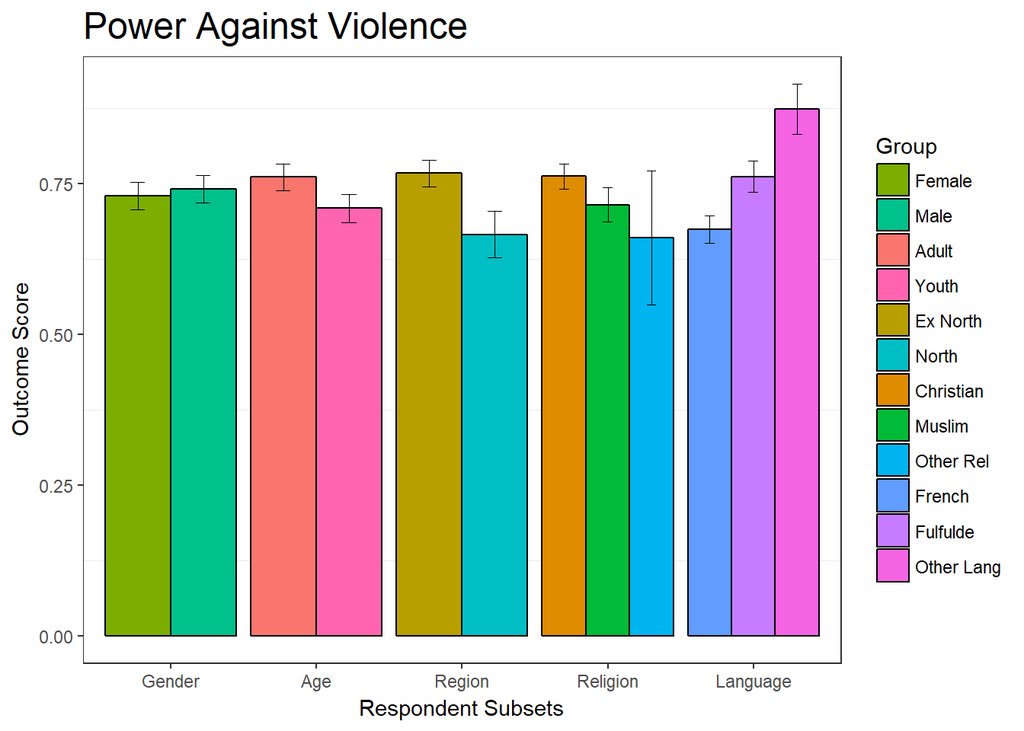

Respondents generally agreed that violence and insecurity were problems in their community. On a scale from 0-1, the average score is 0.3098118, and 49.5% strongly agree that violence is a problem in their communities. All subsets feel similarly, but people who responded in a language other than French/Fulfulde perceive less violence and insecurity in their communities than people who responded in French/Fulfulde. Overall, this questions shows that most people in Cameroon are concerned about violence and insecurity.

The take-away for these three questions is that respondents are concerned about violence, but feel empowered to speak against it and to make positive changes in their community.

### Knowledge of Legal Assistance

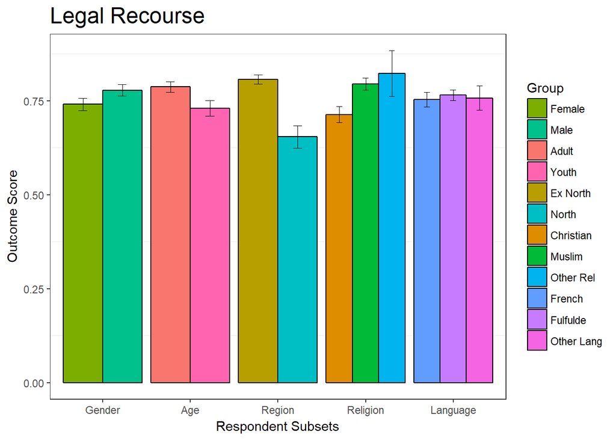

Respondents generally knew how to seek legal recourse if a law is broken, with an average score of 0.76 on a 0-1 scale where 1 corresponds to “strongly agree” and 0 with “strongly disagree”. The modal response is “strongly agree”, with over 60% of respondents answering that way. However, there is a stark difference by region: in the extreme north, 66.8% strongly agree and another 15.8% somewhat agree, but in the north only 45.9% agree, and 20.8% somewhat agree. Muslims also report more knowledge of legal recourse than Christians, as do adults compared to youth

## Youth-Old

We ask five questions about youth and elder relations in the survey. These questions are not intended to measure an underlying attitude dimension, so we analyze each in turn rather than combine them into an index. Four of the questions use a 4-point scale from strongly agree to strongly disagree. One question – if youth should be involved in community decisions or if they should follow the lead of their elders – uses binary response options. Three of these questions are generally about elders and two are generally about youth. We use those two structures to analyze the youth-elder relations questions in the next sections.

The three questions about elders all use the strongly agree-strongly disagree scale:

The three questions about elders and elders’ feelings towards youth are on a strongly agree-strongly disagree scale.

- Older people listen to and respect the desires and motivations of younger people.
- Older people understand the world that youth are growing up in.
- The ways in which elders solve problems are still applicable today.

The two questions about youth are on different scales. The first is on a strongly agree-strongly disagree scale, and the second uses binary response options:

- Younger people listen to and respect the desires and motivations of their elders.
- Do you think that youth should get involved in your community’s leadership and decision-making, or would you say that youth should follow the lead of their elders?

### Elder Respect for Youth

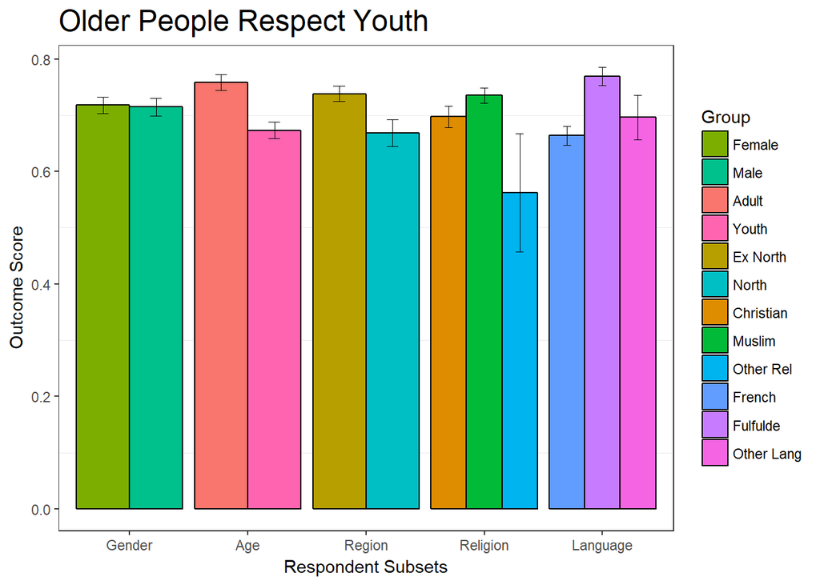

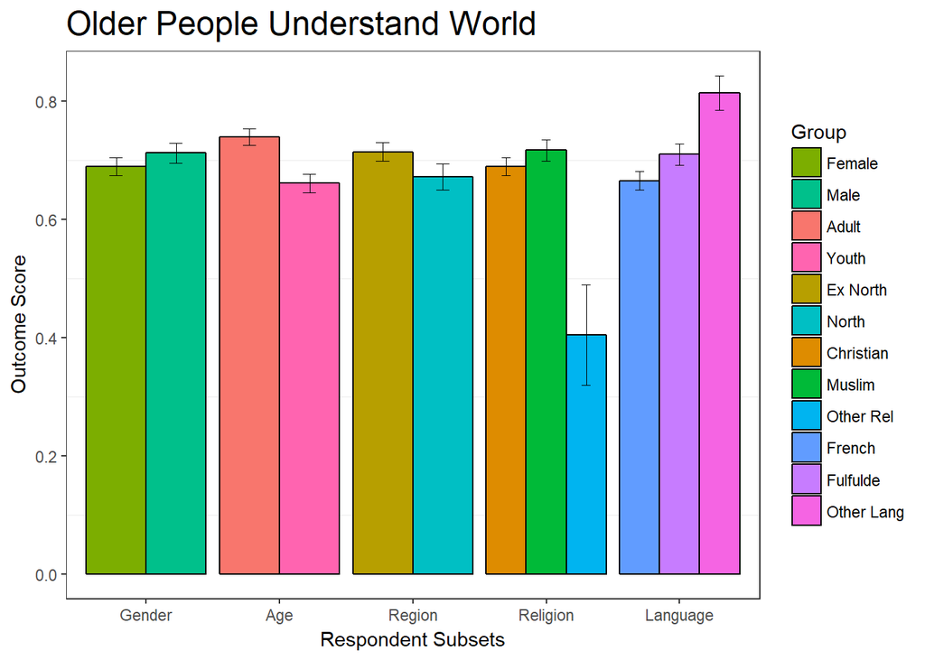

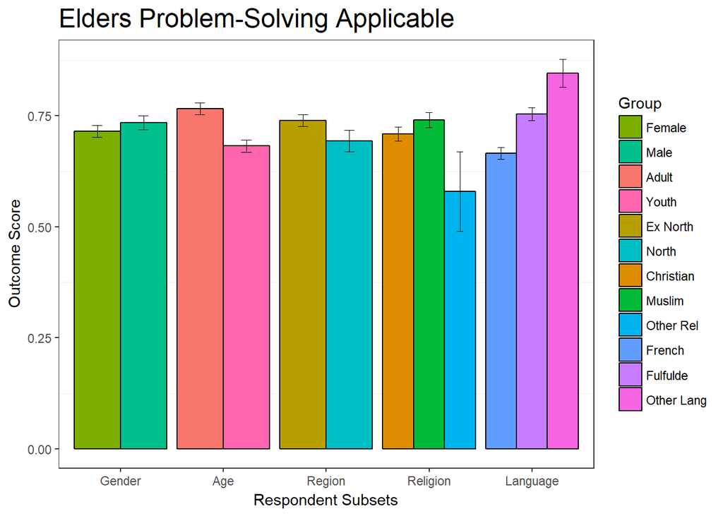

### Youth Respect for Elders

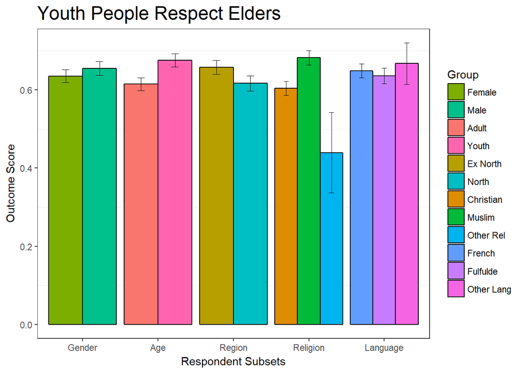

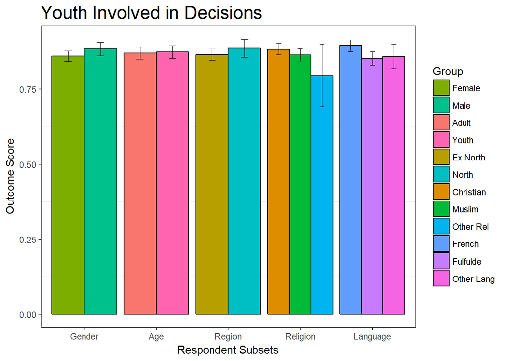

Unlike the questions about elders, these two questions are substantially different, so we discuss them separately.

Overall, perceptions of youth respect for elders is very high. On average respondents score 0.65 on a 0-1 scale when asked if youth respect elders. However, youth score significantly higher than people 30 and over, and the difference is slightly larger when comparing youth under 30 to elders aged 50 and older. Under 60% of respondents 50 and older agree at all to the statement, whereas about 75% of youth agree. Muslims are also more likely to perceive youth as respectful towards elders.

In terms of youth being more involved in community decisions, all subsets of the data agree at about the same rate. 88/% of the sample says that youth should be more involved, and that’s about the same for all of the normal comparisons we make in the data. However, for the youth-old questions we also compared youth to people aged 50 and over, and about 7% fewer people aged 50 and over believe youth should be more involved.

## Violence

We would like to know if people believe violence is a means to achieve goals, or if people generally eschew violence. To learn about that in Cameroon, we measure attitudes about the use of violence. We ask four questions about violence, and they conform to a cohesive index with an alpha of over 0.70. Each question is a scenario in which the respondent might use violence. For each scenario, we ask the respondent if the use of violence is justified always, sometimes, rarely, or never. The four scenarios are:

- Defend one’s religion
- Maintain culture and traditions
- Bring criminals to justice when the government fails to act
- Force the government to change their policies or actions

All questions have been re-scaled so that higher scores are normatively desirable and lower scores are normatively undesirable. An answer of “always” equates to a score of 0 and an answer of “never” equates to a score of 1. The violence index is also scaled from 0-1, and would be 0 if a respondent answered “always” to each questions and would be a 1 if a respondent answered “never” to each question.

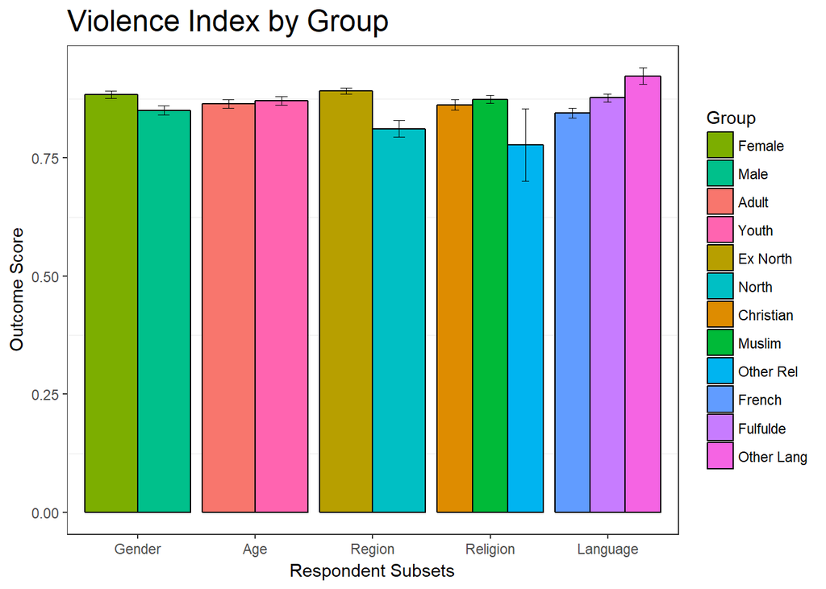

Overall there is strong support against the use of violence; the average score on the index is 0.87 out of 1. All subsets express similar beliefs that violence is not generally acceptable, but people in the north are more accepting of violence than people in the extreme north, by about 7 points on this scale. There are three differences by subsets: (1) women are less accepting of violence than men, (2) people who answered the survey in a language other than French/Fulfulde are less accepting of violence than French/Fulfulde speakers, and (3) people who answered with Fulfulde are less accepting of violence than people who answered in French.

## Institutional Confidence

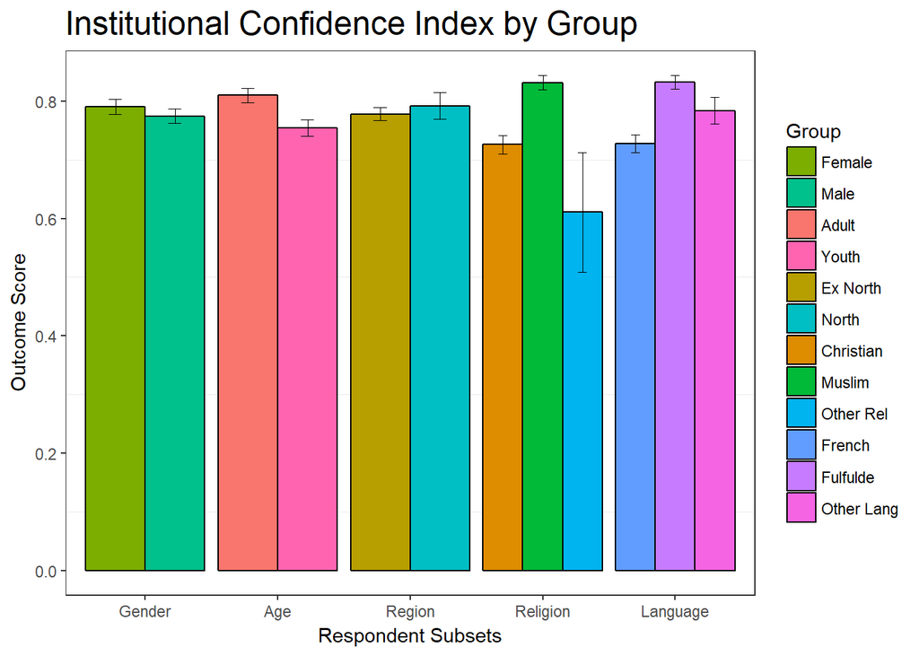

We asked about respondent’s confidence in institutions. We asked about:

- Your local community radio station
- Juidicial system
- Religious leaders
- Traditional leaders
- Local government

The confidence that respondents have in these institutions measures the confidence people have generally in civil society and governance institutions. The alpha for these questions is 0.77, indicating a cohesive index measuring one underlying concept. The index is scaled so that higher scores mean more confidence in institutions.

Respondents have strong trust in institutions overall, with a mean score of 0.79 on the 0-1 scale. Adults have more confidence in institutions than youth, and Muslims have more confidence than Christians. People who answered the survey in Fulfulde have more confidence than people who answered the survey in other languages. Confidence for these institutions is fairly high for all institutions except the justice system. For each of the non-justice system institutions, the average score is above 0.75; the average score for the justice system is only about 0.67.

# Technology and Media Access

The next section summarizes the survey results relating to technology and media access. These questions ask about access to utilities like electricity, mobile phone use, and radio and televisin viewing.

## Utilities

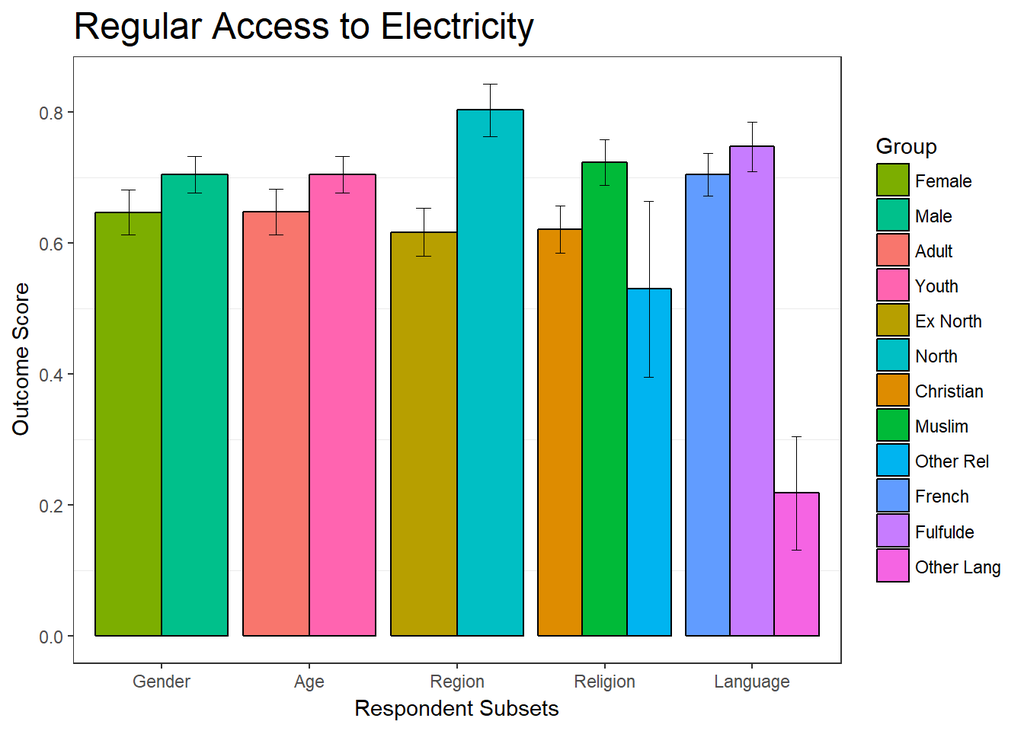

About 67% of respondents reported regular access to electricity, with people in the northern region (81%) reporting much more access to electricity than people in the extreme north (61%). Muslims also report more access to electricity than Christians, but this is only because Muslims are more likely to live in the North, and people in the North are more likely to have electricity. Muslims in the North and Christians in the North are equally likely to have access to electricity, as are Muslims and Christians in the Extreme North. However, people who answered the survey in languages other than French/Fulfulde are *much* less likely to have electrical access, even controlling for region.

## Phones/Tech Access

### Mobile phones

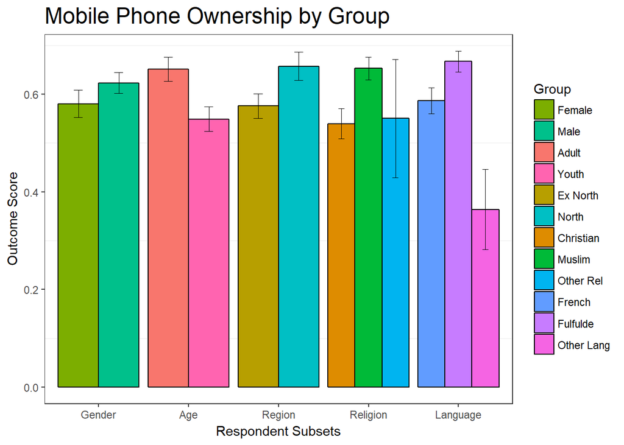

About 60% report access to a simple mobile phone. Adults are more likely to have access than youth, and people in the North more likely than people in the Extreme North. Muslim are more likely to have simple mobile phone access than Chrstians, and people who answered the survey in Fulfulde more likely to have access than those who answered in French, but people who answered in French or Fulfulde are *much* more likely to have access than people who answered in any other language.

### Smartphones

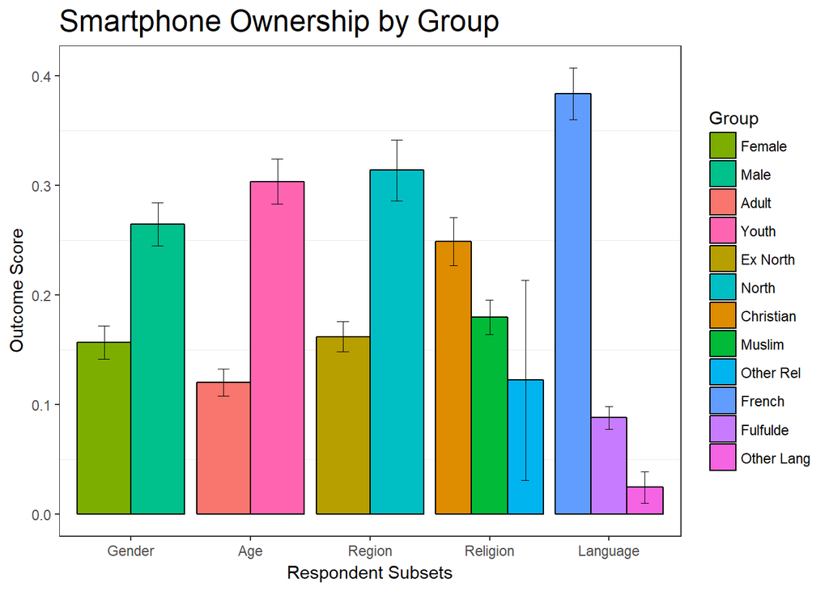

About 20% report access to a smartphone. Here we finally see age and gender differences, with males and young people much more likely to access smartphones than females or older people. This difference by gender is slightly complex, and is only seen among young people – adult males and females access smartphones at about the same rate.

People in the North, who also reported more access to electricity, are much more likely to access smartphones than people in the Extreme North. People who answered the survey in French are much more likely to access smartphones than people who answered in Fulfulde or another language. And Christians are more likely to access smartphones than Muslims, but only because Christians are more likely to be young – Christians and Muslims of the same age access smartphones at the same rate.

### Computers and Tablets

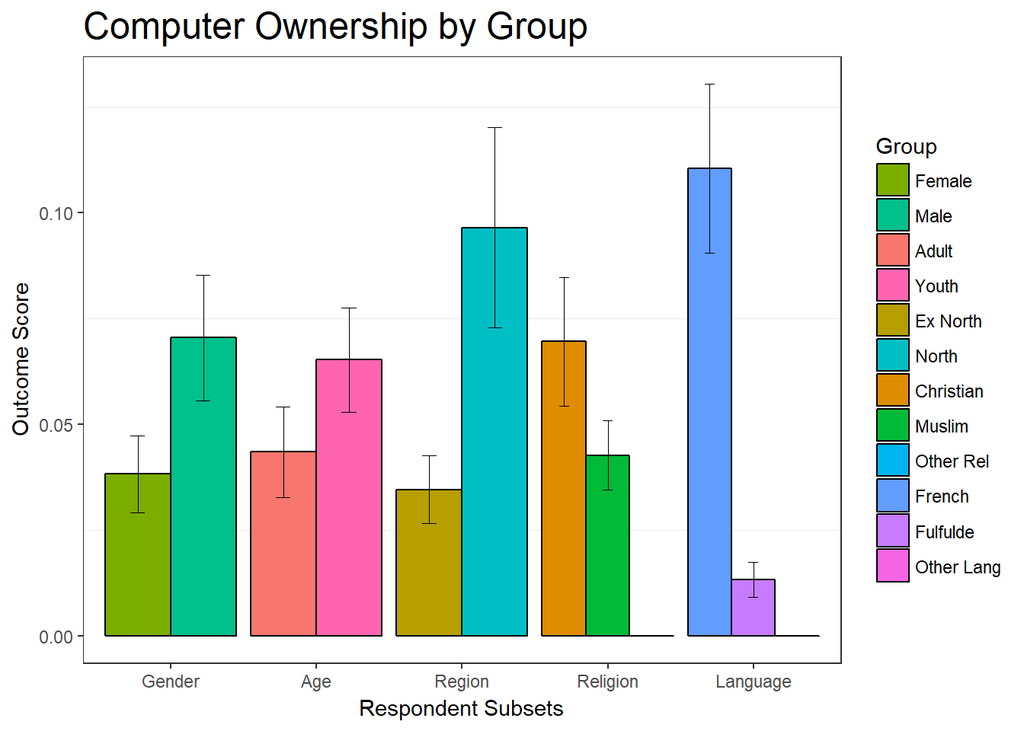

Only 14 people in the survey have tablets, so we cannot say anything statistically about tablet ownership. Of those 14 people, more are men (10) than women (4), and more are in the North (10) than Extreme North (4). And more answered the survey in French (12) than answered in Fulfulde (2) or another language (0).

## Mobile Service Providers

We asked respondents who at least accessed a mobile phone which mobile service providers (MSP) they used. The most popular MSPs are Orange, which 52% of the sample reported using, and MTN, which is used by about 46% of the sample. The only other MSP used by a large proportion of the sample is Nextel, used by about 28% of respondents. Only 2-3% of the sample used any other MSP.

## OS

We asked respondents who access smartphones which operating system (OS) they used [^10]. The most popular OS by far is Android, used by about 16% of the sample and about 80% of smartphones users. Next is Blackberry, Windows, and Apple’s iOS, but those are all used by about 1% or less of the population, and no more than 6% of the 203 smartphone users in the sample.

## Internet Use

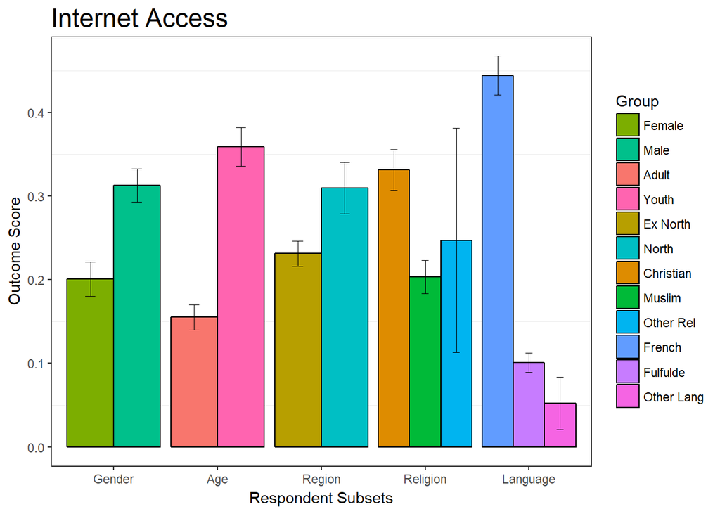

About 25% of the sample report access to the internet. Males, young people, northerners, and people who answered the surveys in French all access the internet much more than their comparison groups. The difference between Muslims and Christians is fairly large, and in the sample 33% of Christians compared to 20% of Muslims access the internet, but this is completely due to more Christians being younger, and young people accessing the internet more often. Muslims and Christians of the same age access the internet at the same rate.

If respondents used the internet, we also asked respondents on what device he/she accessed the internet, and in what location he/she used the internet. Accessing the internet on a mobile phone is by far the most popular method, and 16% of the sample/74% of internet users access the internet on their mobile device. The most popular locations for computer access are at home (6%, 27%) or at an internet cafe (4.8%, 21%). About 3% of the sample and 12%-13% of internet users access the internet either at work or on a friend or family member’s computer/phone. Zero people used the internet on tablets.

## Media Frequency

# Equal Access Programs

## Radio

We asked respondents about their listening to: (1) Douniarou Derkeen, (2) Dabalaye, (3) Chabab-al-Haye, and (4) Dandal Kura. Dabalaye, Chabab-al-Haye, and Dandal Kura are all aired in minority languages spoken by very few people in this sample[^11], so we have very few listeners of those progams. Only nine people listened to Dabalaye; only three people listened to Chabab, and zero respondents listened to Dandal_Kura. As a result, here we show only the viewership of Douniarou Derkeen, which is aired in Fulfulde, the language primarily spoken by a plurality of survey respondents (352 people, or about 35% of the sample). 296 respondents listened to Douniarou Derkeen – about 30% of the entire sample, and 40% of radio listeners.

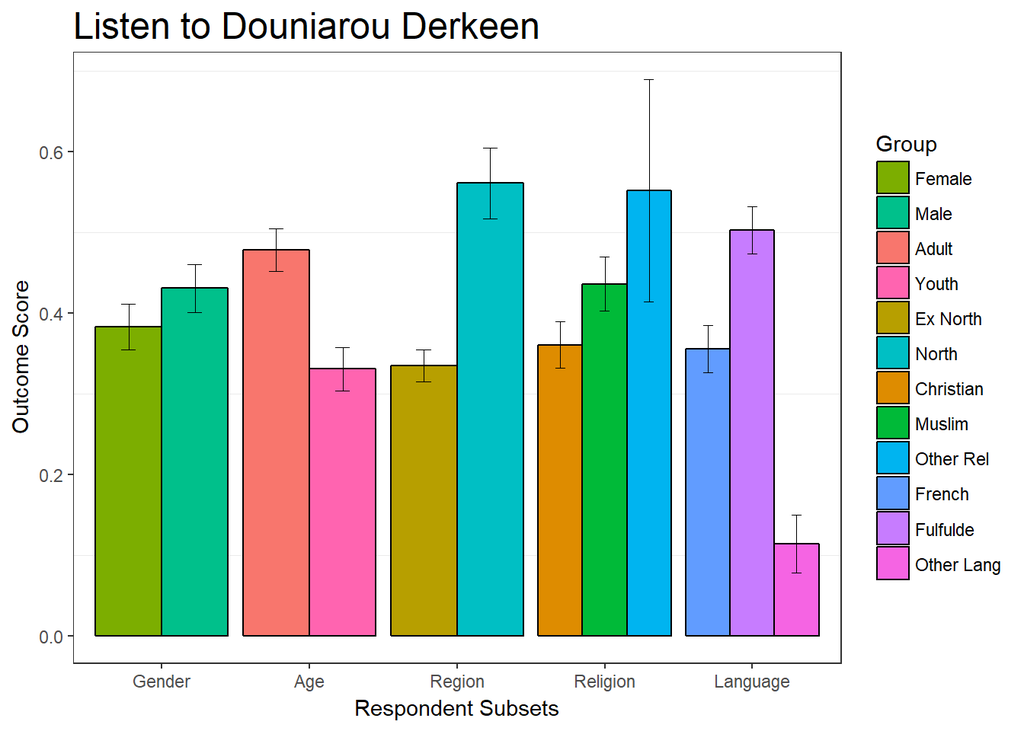

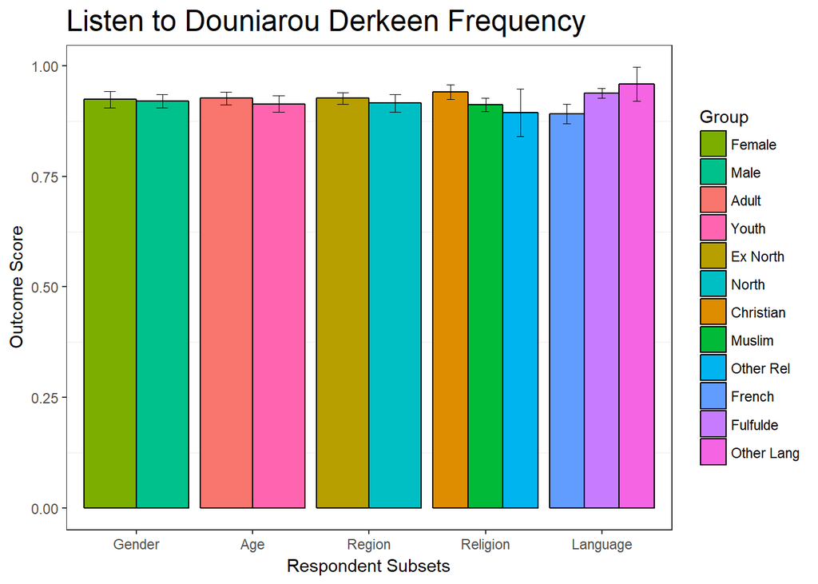

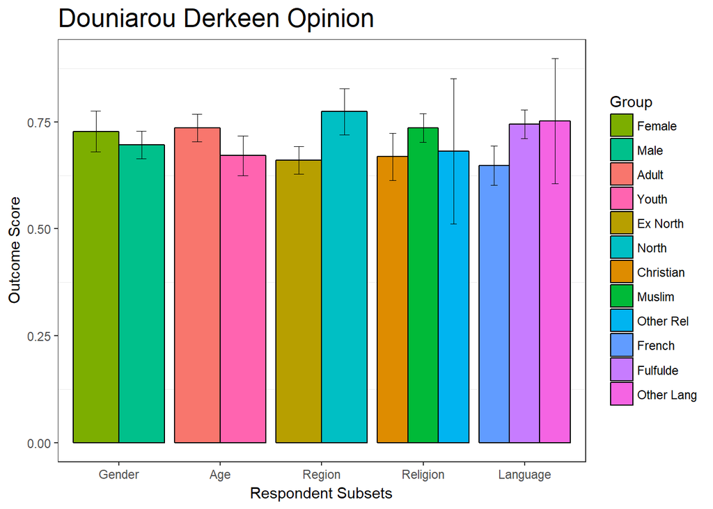

Douniarou Derkeen is especially popular in the Northern region, where 55% of radio listeners listen, compared to 34% in the Extreme North. Young people also listen with less frequency than older people, with 32% of radio listeners under 30 listening and about 47% of radio listeners 30 and over listening[^12]. People who answered the survey in Fulfulde are also more likely to listen than people who answered in any other language, as expected. If we look at listenership by primary language spoken, Douniarou Derkeen has popularity even among people who primarily speak other languages. 43% of people who primarily speak Fulfulde listen, but a full 39% of people who primarily speak French also listen, and even 11% of Arabic-primary speakers and 2 of the 9 Kanuri-primary speakers listen – more than who listen to Dandal Kura.

## Arewa24

# Conclusion

# Caveats

This survey possesses some indicators of Agreement Bias. Many of the questions do not generate variation and almost all respondents agrees or say yes, and so we cannot differentiate between “agreement” as an attitude vs. “agreement” as a habitual survey response. This is a call for reverse coding, survey experiments, and maybe for more professional enumerators, since mass Agreement Bias could indicate that the data quality is below average.

It’s also possible that the past radio programs of PDEV worked extremely well and we actually observe a “ceiling effect”, wherein people already exhibit very positive attitudes, making it difficult to make these attitudes better[^14]. In that case, the goal of the Cameroon Peace Promotion Project should be the maintenance of positive attitudes, rather than persuasion of people with negative attitudes.

# Appendices

## Appendix 1

We attempted a randomization experiment to measure attitudes towards people from other religions. In the randomization experiment, we asked respondents if they would live in a community that was **5%/25%/50%/75%** members of a different religion. The percentage is randomized, and we hypothesized that fewer people would be willing to live in a community as the percentage of outgroup members increased. However, the randomization experiment did not work. Virtually everyone said yes in all conditions. This either indicates unprecedented levels of religious tolerance, the Hawthorne Effect wherein subjects learn the correct response to survey questions, or enumerator error in administering the survey experiment.

# References

[^1]: There are many other ways to think about responses to survey questions. For example, we should keep in mind that the response scale given to respondents frames the acceptable responses. A scale of TV watching that includes options (daily, weekly, monthly, yearly) will generate different responses than a scale that includes (daily, almost every day, a few times per week, weekly, monthly). And previous questions influence subsequent questions by making certain ideas salient in the minds of respondents.
[^2]: This is also true for interviews and focus groups. Those methods mitigate the problem by extensive probing and respondent interaction. Surveys tend to mitigate this problem by using an index and asking many questions to measure the same underlying concept.
[^3]: for example, on a cold and rainy day people tend to give more pessimistic answers, whereas on a warm and sunny day people tend to give more optimistic answers (Schwartz cite)
[^4]: This assumes random sampling; supporters of candidate A and candidate B must be equally likely to answer the survey.
[^5]: Though we display estimates for Christians, Muslims, and people from other religions, only 11 people responded with a religion other than Christianity or Islam. As such, these estimates are extremely imprecise.
[^6]: An important point about interview language: people answering the survey in a language other than French/Fulfulde are only in the extreme north.
[^7]: Due to the relatively low number of non-French/Fulfulde speakers, there is much more random noise in the measurement of their opinions.
[^8]: We also conducted a survey experiment, which was unsuccessful and is described in the appendix.
[^9]: this is also true for people who are neither Christian or Muslim, but since these are only 2/11 people we should not place too much weight in this conclusion.
[^10]: We also asked tablet users about their OS, but the sample lacks enough tablet users to report any statistics about tablet operating systems.
[^11]: Dabalaye and Chabab-al-Haye are aired in Arabic, spoken by 121 people in the areas airing the program. Dandal Kura is aired in Kanuri, spoken by only 17 people in this sample.
[^12]: This is as a percentage of radio listeners. We see the same trend looking at the whole population, where 24% of young people listen compared to 35% of older people.
[^13]: Acquiescence Bias, also called Agreement Bias, is a commonly observed bias in human communication and affects most forms of data collection, including surveys, interviews, and focus groups.
[^14]: Another possibility is that the respondents *express* but do not *hold* positive attitudes. Instead of being more tolerant due to PDEV programs, they may instead have learned how to respond to surveys like this.